# Practice

2025-06-18

```r
library(tidyverse)
```

```r
library(ggplot2)
library(dplyr)
```

# Case Study #1: Differences in Severity of Case based on Hospitalized Patients by Age

## Introduction and Data Background

Between the years of 2022 and 2024, Denmark was hit with the intense impact of the Coronavirus diseases (COVID-19). Data was cataloged by the national government, focusing on initial infection, reinfection, vaccination, key demographics (age, region, gender), and infection strand type. This dataset is for educational purposes, used for epidemiological modeling.

Link: https://www.kaggle.com/datasets/khushikyad001/covid-19-reinfection-and-health-dataset

Based on the data provided, the impact of COVID-19 was devastating. Most importantly, identifying how this impact varies over different age groups is crucial to preparing immediate care to those who need it most. In order to identify this impact, we focused on distinguishing age groups using the severity of a case, either Critical (in life-threatening conditions) or High (extreme impact). The research question is: is there a difference between the true average age of hospitalized COVID patients triaged as a critical vs. high case?

## Importing and Tidying the Data

```r
covid <- read.csv("C:/Users/VanhiChava/Downloads/covid.csv")
head(covid)
```

```
##   Patient_ID Age Gender      Region Preexisting_Condition Date_of_Infection
## 1          1  69   Male Hovedstaden               Obesity         6/21/2022
## 2          2  38   Male    Sjælland                Asthma          2/2/2024
## 3          3  41 Female  Syddanmark          Hypertension         5/28/2023
## 4          4  81 Female Hovedstaden                Asthma         8/13/2023
## 5          5  50 Female  Syddanmark        Cardiovascular         3/10/2023
## 6          6  66   Male    Sjælland        Cardiovascular          7/4/2022
##   COVID_Strain Symptoms Severity Hospitalized Hospital_Admission_Date
## 1        Delta     Mild Moderate          Yes               1/13/2025
## 2      XBB.1.5     Mild Moderate           No
## 3         Beta     Mild     High          Yes                3/7/2025
## 4        Delta   Severe     High           No
## 5        Delta     Mild     High           No
## 6      Omicron Moderate Moderate           No
##   Hospital_Discharge_Date ICU_Admission Ventilator_Support Recovered
```

[output cut: 27 more lines]

```r
age_covid <- covid %>%
  filter(Hospitalized == "Yes") %>%
  group_by(Severity) %>%
  summarize(mean_Age = mean(Age),
            total = n(),
            sd_Age = sd(Age))
age_covid
```

```
## # A tibble: 4 × 4
##   Severity mean_Age total sd_Age
##   <chr>       <dbl> <int>  <dbl>
## 1 Critical     55.1   199   21.5
## 2 High         51.9   216   20.7
## 3 Low          52.2   221   20.9
## 4 Moderate     55.1   240   20.4
```

## Graphical Representation

#### Scatter Plot Comparison of All Hospitalized Patients

The purpose of this plot is to showcase the similarity in age of patients no matter the COVID-19 case severity. There are no specific patterns to identify in the plot to distinguish that age has a true impact on the classification of severity. That being said, preforming a confidence test will provide more information on finding this distinction.

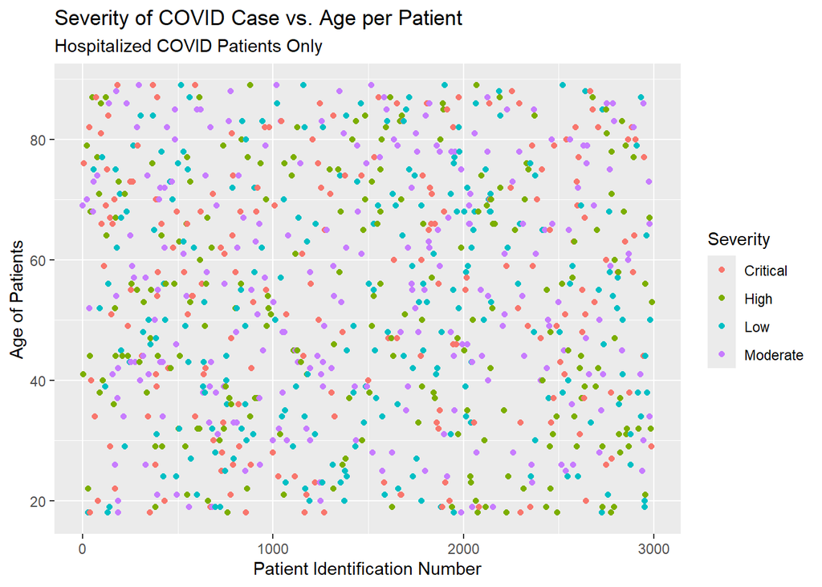

```r
hosp_covid <- covid %>%
  filter(Hospitalized == "Yes")

ggplot(hosp_covid, aes(x = Patient_ID, y = Age)) +
  geom_point(aes(color = Severity)) +
  labs(x = "Patient Identification Number",
       y = "Age of Patients",
       title = "Severity of COVID Case vs. Age per Patient",
       subtitle = "Hospitalized COVID Patients Only")
```

#### Bar Plot Comparison

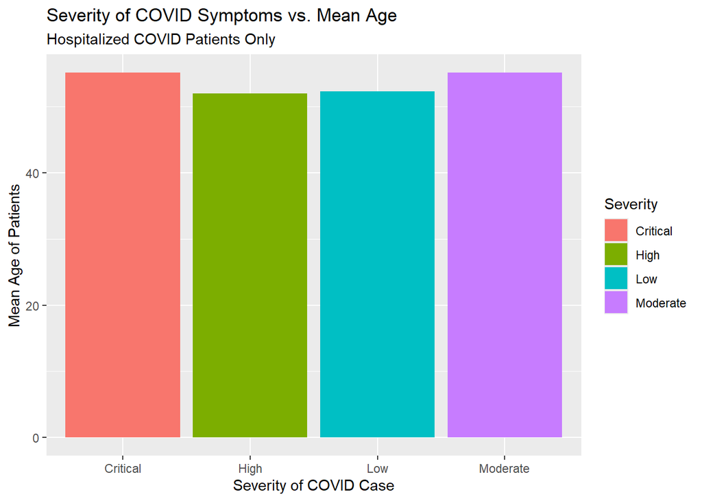

```r
ggplot(age_covid, aes(x = Severity, y = mean_Age, fill = Severity)) + geom_col() +
labs(x = "Severity of COVID Case",
       y = "Mean Age of Patients",
       title = "Severity of COVID Symptoms vs. Mean Age",
      subtitle = "Hospitalized COVID Patients Only")
```

## Statistical Analysis

This statistical study will be preformed using a 98% confidence interval for optimal identification of a distinction between the true mean age of hospitalized COVID patients classified as critical subtracted by high severity (Critical - High).

Variable Definitions

```r
#Critical Patient Statistics
xbarc <- age_covid$mean_Age[1]
sdc <- age_covid$sd_Age[1]
nc <- age_covid$total[1]

#High Severity Patient Statistics
xbarh <- age_covid$mean_Age[2]
sdh <- age_covid$sd_Age[2]
nh <- age_covid$total[2]

nc;nh
```

```
## [1] 199
```

```
## [1] 216
```

The assumption that patients classified as having a critical case versus a high severity case is made. Both sample sizes are large enough to induce the Central Limit Theorem so both mean distributions are considered Normal. As a result, the difference in mean distributions is additionally Normal.

The approximation of the degree of freedom is done by using the Welch Procedure.

```r
point_estimate <- xbarc - xbarh

#Critical Value
welch_top <- (((sdc^2)/nc) + ((sdh^2)/nh))^2
welch_bottom <- ((((sdc^2)/nc)^2)/(nc-1)) + ((((sdh^2)/nh)^2)/(nh-1))
w <- welch_top / welch_bottom
cv <- qt(0.99, df = w)

#Standard Error
se <- sqrt(((sdc^2)/nc) + ((sdh^2)/nh))

#Building the Confidence Interval
c(point_estimate - cv*se, point_estimate + cv*se)
```

```
## [1] -1.737279  7.948892
```

## Conclusion

We are 98% confident that the difference in true mean age of a hospitalized COVID patient classified as critical and high severity lies within the interval (-1.737, 7.949). Since 0 is in the interval, we do not have significant evidence of a true difference in the mean age of hospitalized COVID patients classified as critical versus high severity.

The severity of COVID-19 symptoms is not proven to be significant in distinguishing specific age groups of patients. In the future, we must explore other markers of patients to understand a true indicator of distinction of age groups, such as pre-existing health conditions, region, strand contracted, or reinfection.